# Observing Crime in Washington DC

### By Soojee Fee and Zaal Belihomji

As the capital of the United States, Washington DC is one the biggest tourist attractions within our country. Many people enjoy visiting the historical buildings, popular restaurants and attractive scenery. As a country, we should strive to make our capital as accessible and inviting as possible to both incoming visitors and locals. In order to achieve this goal, we must identify the trends persisting in Washington DC crime data, and come up with effective measures to address this issue. Our citizens deserve to feel safe in such a notable and prominent part of America’s history. By researching the patterns of past data, we are able to infer and predict the trends of upcoming years and induct reasoning for previous behavior. It is our goal to help contribute to the limitation and eradication of crime in our country’s capital, and formulate ways to address the common trends.

```python
import numpy as np
import pandas as pd
import matplotlib.pyplot as plt
import geopandas as gpd
import folium
import seaborn as sns
from sklearn.linear_model import LogisticRegression
from sklearn.metrics import accuracy_score, classification_report
import folium
from sklearn.ensemble import RandomForestClassifier
from sklearn.model_selection import train_test_split
```

# Collecting our Data

In order to begin our research, we must collect our data from the following dataset: https://www.kaggle.com/datasets/vinchinzu/dc-metro-crime-data

We do this by reading the csv into our dataframe. As you can tell, there will be values inside the data frame that do not hold a specific value.

```python
# Data Collection: read the data

df = pd.read_csv("/content/dc_crime_add_vars.csv")
df
```

|  | Unnamed: 0 | X | REPORT_DAT | SHIFT | OFFENSE | METHOD | BLOCK | DISTRICT | PSA | WARD | ... | year | month | day | hour | minute | second | EW | NS | quad | crimetype |
| --- | --- | --- | --- | --- | --- | --- | --- | --- | --- | --- | --- | --- | --- | --- | --- | --- | --- | --- | --- | --- | --- |
| 0 | 1 | 1 | 8/31/2008 8:47:00 PM | EVENING | THEFT/OTHER | OTHERS | 3500 - 3599 BLOCK OF R STREET NW | 2.0 | 206.0 | 2 | ... | 2008 | 8 | 31 | 20 | 47 | 0 | West | North | Northwest | Non-Violent |
| 1 | 2 | 2 | 9/1/2008 12:45:00 AM | MIDNIGHT | MOTOR VEHICLE THEFT | OTHERS | 2000 - 2015 BLOCK OF O STREET NW | 2.0 | 208.0 | 2 | ... | 2008 | 9 | 1 | 0 | 45 | 0 | West | North | Northwest | Non-Violent |
| 2 | 3 | 3 | 9/1/2008 3:00:00 AM | MIDNIGHT | THEFT/OTHER | OTHERS | 700 - 799 BLOCK OF 11TH STREET NW | 1.0 | 101.0 | 2 | ... | 2008 | 9 | 1 | 3 | 0 | 0 | East | North | Northeast | Non-Violent |
| 3 | 4 | 4 | 9/9/2008 7:46:00 AM | DAY | THEFT/OTHER | OTHERS | 1700 - 1799 BLOCK OF P STREET NW | 2.0 | 208.0 | 2 | ... | 2008 | 9 | 9 | 7 | 46 | 0 | West | North | Northwest | Non-Violent |
| 4 | 5 | 5 | 8/24/2008 8:00:00 PM | EVENING | MOTOR VEHICLE THEFT | OTHERS | 500 - 599 BLOCK OF INDIANA AVENUE NW | 1.0 | 102.0 | 2 | ... | 2008 | 8 | 24 | 20 | 0 | 0 | East | North | Northeast | Non-Violent |
| ... | ... | ... | ... | ... | ... | ... | ... | ... | ... | ... | ... | ... | ... | ... | ... | ... | ... | ... | ... | ... | ... |
| 342862 | 342863 | 342863 | 3/21/2008 1:00:00 PM | DAY | MOTOR VEHICLE THEFT | OTHERS | 2200 - 2230 BLOCK OF 6TH STREET NW | 3.0 | 305.0 | 1 | ... | 2008 | 3 | 21 | 13 | 0 | 0 | East | North | Northeast | Non-Violent |
| 342863 | 342864 | 342864 | 3/21/2008 9:08:00 PM | EVENING | THEFT/OTHER | OTHERS | 3300 - 3341 BLOCK OF 16TH STREET NW | 3.0 | 302.0 | 1 | ... | 2008 | 3 | 21 | 21 | 8 | 0 | West | North | Northwest | Non-Violent |
| 342864 | 342865 | 342865 | 3/21/2008 4:30:00 PM | EVENING | THEFT/OTHER | OTHERS | 1500 - 1530 BLOCK OF PARK ROAD NW | 3.0 | 302.0 | 1 | ... | 2008 | 3 | 21 | 16 | 30 | 0 | East | North | Northeast | Non-Violent |
| 342865 | 342866 | 342866 | 3/21/2008 5:15:00 PM | EVENING | MOTOR VEHICLE THEFT | OTHERS | 3200 - 3299 BLOCK OF PARK PLACE NW | 3.0 | 302.0 | 1 | ... | 2008 | 3 | 21 | 17 | 15 | 0 | East | North | Northeast | Non-Violent |
| 342866 | 342867 | 342867 | 3/21/2008 6:30:00 PM | EVENING | ROBBERY | GUN | 2200 - 2299 BLOCK OF GEORGIA AVENUE NW | 3.0 | 306.0 | 1 | ... | 2008 | 3 | 21 | 18 | 30 | 0 | East | North | Northeast | Violent |

342867 rows × 32 columns

# Tidying our Data

We then drop the NAN values so that each crime entry in our dataset can be used for the rest of the tutorial.

```python
df = df.dropna()
df
```

|  | Unnamed: 0 | X | REPORT_DAT | SHIFT | OFFENSE | METHOD | BLOCK | DISTRICT | PSA | WARD | ... | year | month | day | hour | minute | second | EW | NS | quad | crimetype |
| --- | --- | --- | --- | --- | --- | --- | --- | --- | --- | --- | --- | --- | --- | --- | --- | --- | --- | --- | --- | --- | --- |
| 0 | 1 | 1 | 8/31/2008 8:47:00 PM | EVENING | THEFT/OTHER | OTHERS | 3500 - 3599 BLOCK OF R STREET NW | 2.0 | 206.0 | 2 | ... | 2008 | 8 | 31 | 20 | 47 | 0 | West | North | Northwest | Non-Violent |
| 1 | 2 | 2 | 9/1/2008 12:45:00 AM | MIDNIGHT | MOTOR VEHICLE THEFT | OTHERS | 2000 - 2015 BLOCK OF O STREET NW | 2.0 | 208.0 | 2 | ... | 2008 | 9 | 1 | 0 | 45 | 0 | West | North | Northwest | Non-Violent |
| 2 | 3 | 3 | 9/1/2008 3:00:00 AM | MIDNIGHT | THEFT/OTHER | OTHERS | 700 - 799 BLOCK OF 11TH STREET NW | 1.0 | 101.0 | 2 | ... | 2008 | 9 | 1 | 3 | 0 | 0 | East | North | Northeast | Non-Violent |
| 3 | 4 | 4 | 9/9/2008 7:46:00 AM | DAY | THEFT/OTHER | OTHERS | 1700 - 1799 BLOCK OF P STREET NW | 2.0 | 208.0 | 2 | ... | 2008 | 9 | 9 | 7 | 46 | 0 | West | North | Northwest | Non-Violent |
| 4 | 5 | 5 | 8/24/2008 8:00:00 PM | EVENING | MOTOR VEHICLE THEFT | OTHERS | 500 - 599 BLOCK OF INDIANA AVENUE NW | 1.0 | 102.0 | 2 | ... | 2008 | 8 | 24 | 20 | 0 | 0 | East | North | Northeast | Non-Violent |
| ... | ... | ... | ... | ... | ... | ... | ... | ... | ... | ... | ... | ... | ... | ... | ... | ... | ... | ... | ... | ... | ... |
| 342862 | 342863 | 342863 | 3/21/2008 1:00:00 PM | DAY | MOTOR VEHICLE THEFT | OTHERS | 2200 - 2230 BLOCK OF 6TH STREET NW | 3.0 | 305.0 | 1 | ... | 2008 | 3 | 21 | 13 | 0 | 0 | East | North | Northeast | Non-Violent |
| 342863 | 342864 | 342864 | 3/21/2008 9:08:00 PM | EVENING | THEFT/OTHER | OTHERS | 3300 - 3341 BLOCK OF 16TH STREET NW | 3.0 | 302.0 | 1 | ... | 2008 | 3 | 21 | 21 | 8 | 0 | West | North | Northwest | Non-Violent |
| 342864 | 342865 | 342865 | 3/21/2008 4:30:00 PM | EVENING | THEFT/OTHER | OTHERS | 1500 - 1530 BLOCK OF PARK ROAD NW | 3.0 | 302.0 | 1 | ... | 2008 | 3 | 21 | 16 | 30 | 0 | East | North | Northeast | Non-Violent |
| 342865 | 342866 | 342866 | 3/21/2008 5:15:00 PM | EVENING | MOTOR VEHICLE THEFT | OTHERS | 3200 - 3299 BLOCK OF PARK PLACE NW | 3.0 | 302.0 | 1 | ... | 2008 | 3 | 21 | 17 | 15 | 0 | East | North | Northeast | Non-Violent |
| 342866 | 342867 | 342867 | 3/21/2008 6:30:00 PM | EVENING | ROBBERY | GUN | 2200 - 2299 BLOCK OF GEORGIA AVENUE NW | 3.0 | 306.0 | 1 | ... | 2008 | 3 | 21 | 18 | 30 | 0 | East | North | Northeast | Violent |

325340 rows × 32 columns

Along with this idea, we drop irrelevant rows from our data frame that do not serve use in this report.

```python
df.columns
new_order = ['Unnamed: 0', 'X', 'REPORT_DAT', 'year', 'SHIFT', 'OFFENSE', 'METHOD', 'BLOCK',
       'DISTRICT', 'PSA', 'WARD', 'ANC', 'NEIGHBORHOOD_CLUSTER', 'BLOCK_GROUP',
       'CENSUS_TRACT', 'VOTING_PRECINCT', 'CCN', 'START_DATE', 'END_DATE',
       'XBLOCK', 'YBLOCK', 'optional', 'date', 'month', 'day', 'hour',
       'minute', 'second', 'EW', 'NS', 'quad', 'crimetype']
df = df[new_order]
```

```python
df = df.drop(['ANC', 'BLOCK_GROUP', 'CENSUS_TRACT', 'VOTING_PRECINCT', 'CCN', 'START_DATE',
       'END_DATE', 'quad', 'date', 'month', 'day', 'minute', 'second'], axis = 1)

print("Our column names are: ")
print(df.columns)
df
```

```
Our column names are:
Index(['Unnamed: 0', 'X', 'REPORT_DAT', 'year', 'SHIFT', 'OFFENSE', 'METHOD',
       'BLOCK', 'DISTRICT', 'PSA', 'WARD', 'NEIGHBORHOOD_CLUSTER', 'XBLOCK',
       'YBLOCK', 'optional', 'hour', 'EW', 'NS', 'crimetype'],
      dtype='object')
```

|  | Unnamed: 0 | X | REPORT_DAT | year | SHIFT | OFFENSE | METHOD | BLOCK | DISTRICT | PSA | WARD | NEIGHBORHOOD_CLUSTER | XBLOCK | YBLOCK | optional | hour | EW | NS | crimetype |
| --- | --- | --- | --- | --- | --- | --- | --- | --- | --- | --- | --- | --- | --- | --- | --- | --- | --- | --- | --- |
| 0 | 1 | 1 | 8/31/2008 8:47:00 PM | 2008 | EVENING | THEFT/OTHER | OTHERS | 3500 - 3599 BLOCK OF R STREET NW | 2.0 | 206.0 | 2 | Cluster 4 | -77.070209 | 38.913633 | True | 20 | West | North | Non-Violent |
| 1 | 2 | 2 | 9/1/2008 12:45:00 AM | 2008 | MIDNIGHT | MOTOR VEHICLE THEFT | OTHERS | 2000 - 2015 BLOCK OF O STREET NW | 2.0 | 208.0 | 2 | Cluster 6 | -77.045323 | 38.908564 | True | 0 | West | North | Non-Violent |
| 2 | 3 | 3 | 9/1/2008 3:00:00 AM | 2008 | MIDNIGHT | THEFT/OTHER | OTHERS | 700 - 799 BLOCK OF 11TH STREET NW | 1.0 | 101.0 | 2 | Cluster 8 | -77.027045 | 38.899057 | True | 3 | East | North | Non-Violent |
| 3 | 4 | 4 | 9/9/2008 7:46:00 AM | 2008 | DAY | THEFT/OTHER | OTHERS | 1700 - 1799 BLOCK OF P STREET NW | 2.0 | 208.0 | 2 | Cluster 6 | -77.040089 | 38.909638 | True | 7 | West | North | Non-Violent |
| 4 | 5 | 5 | 8/24/2008 8:00:00 PM | 2008 | EVENING | MOTOR VEHICLE THEFT | OTHERS | 500 - 599 BLOCK OF INDIANA AVENUE NW | 1.0 | 102.0 | 2 | Cluster 8 | -77.019377 | 38.894573 | True | 20 | East | North | Non-Violent |
| ... | ... | ... | ... | ... | ... | ... | ... | ... | ... | ... | ... | ... | ... | ... | ... | ... | ... | ... | ... |
| 342862 | 342863 | 342863 | 3/21/2008 1:00:00 PM | 2008 | DAY | MOTOR VEHICLE THEFT | OTHERS | 2200 - 2230 BLOCK OF 6TH STREET NW | 3.0 | 305.0 | 1 | Cluster 3 | -77.020640 | 38.919610 | True | 13 | East | North | Non-Violent |
| 342863 | 342864 | 342864 | 3/21/2008 9:08:00 PM | 2008 | EVENING | THEFT/OTHER | OTHERS | 3300 - 3341 BLOCK OF 16TH STREET NW | 3.0 | 302.0 | 1 | Cluster 2 | -77.036470 | 38.932120 | True | 21 | West | North | Non-Violent |
| 342864 | 342865 | 342865 | 3/21/2008 4:30:00 PM | 2008 | EVENING | THEFT/OTHER | OTHERS | 1500 - 1530 BLOCK OF PARK ROAD NW | 3.0 | 302.0 | 1 | Cluster 2 | -77.035410 | 38.931240 | True | 16 | East | North | Non-Violent |
| 342865 | 342866 | 342866 | 3/21/2008 5:15:00 PM | 2008 | EVENING | MOTOR VEHICLE THEFT | OTHERS | 3200 - 3299 BLOCK OF PARK PLACE NW | 3.0 | 302.0 | 1 | Cluster 2 | -77.018410 | 38.931020 | True | 17 | East | North | Non-Violent |
| 342866 | 342867 | 342867 | 3/21/2008 6:30:00 PM | 2008 | EVENING | ROBBERY | GUN | 2200 - 2299 BLOCK OF GEORGIA AVENUE NW | 3.0 | 306.0 | 1 | Cluster 3 | -77.021910 | 38.919490 | True | 18 | East | North | Violent |

325340 rows × 19 columns

# Data Visualization

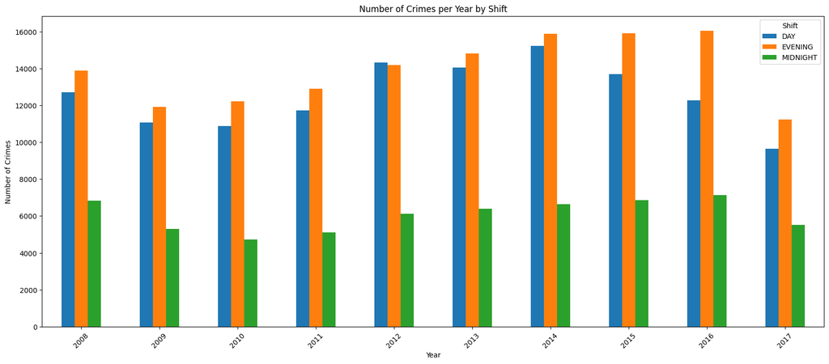

```python
crime_by_year_shift = df.groupby(['year', 'SHIFT']).size().unstack(fill_value=0)
crime_by_year_shift.plot(kind='bar', stacked=False, figsize=(20, 8))
plt.title('Number of Crimes per Year by Shift')
plt.xlabel('Year')
plt.ylabel('Number of Crimes')
plt.xticks(rotation=45)
plt.legend(title='Shift')
plt.show()
```

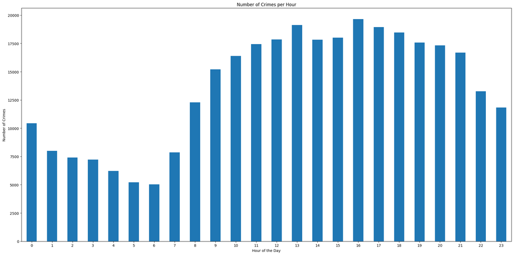

```python
# ANALYSIS / Visualization
crime_counts_per_hour = df['hour'].value_counts().sort_index()
plt.figure(figsize=(20, 10))
crime_counts_per_hour.plot(kind='bar')
plt.title('Number of Crimes per Hour')
plt.xlabel('Hour of the Day')
plt.ylabel('Number of Crimes')
plt.xticks(rotation=0)
plt.tight_layout()
plt.show()
```

In our next chart, we observe the number of crimes committed per hour of day categorized by nature. We have two classifications of crimes: violent and nonviolent. This heat chart displays that there were significantly more nonviolent crimes than violent ones observed.

It also displays nonviolent crimes to occur more often during the afternoon and into the evening, and violent crimes to occur more often during the late hours of the night like 11 pm -12 am.

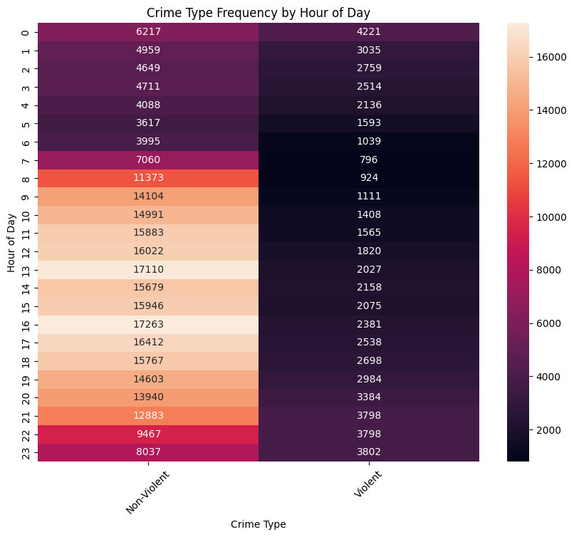

```python
pivot_table = df.pivot_table(index='hour', columns='crimetype', aggfunc='size', fill_value=0)
plt.figure(figsize=(10, 8))
sns.heatmap(pivot_table, annot=True, fmt="d")
plt.title('Crime Type Frequency by Hour of Day')
plt.ylabel('Hour of Day')
plt.xlabel('Crime Type')
plt.xticks(rotation=45)
plt.show()
```

We have a simple bar graph dividing the total number of crimes by shift, and then afterwards, a bar graph dividing the total number of crimes by offense - e.g. theft, assault, homicide. Here, we can clearly conclude that theft is the most common offense committed in the DC area.

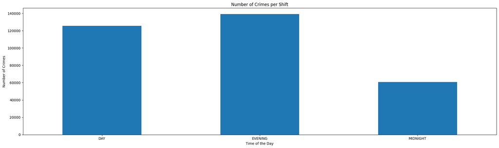

```python
crime_per_shift = df['SHIFT'].value_counts().sort_index()
plt.figure(figsize=(20, 6))
crime_per_shift.plot(kind='bar')
plt.title('Number of Crimes per Shift')
plt.xlabel('Time of the Day')
plt.ylabel('Number of Crimes')
plt.xticks(rotation=0)
plt.tight_layout()
plt.show()
```

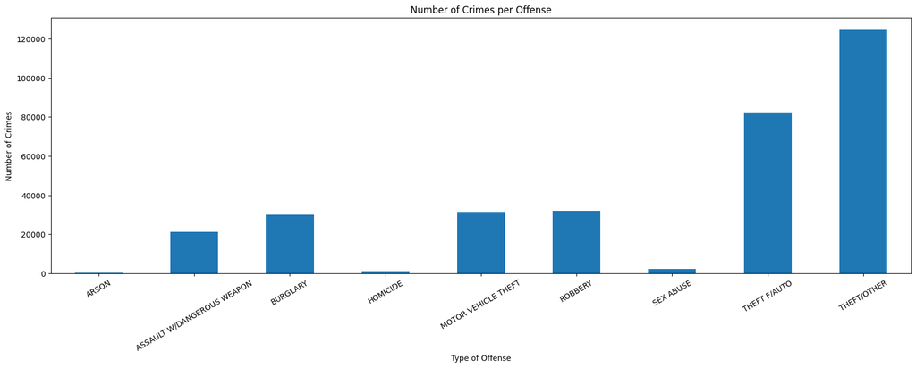

```python
crime_per_offense = df['OFFENSE'].value_counts().sort_index()
plt.figure(figsize=(20, 6))
crime_per_offense.plot(kind='bar')
plt.title('Number of Crimes per Offense')
plt.xlabel('Type of Offense')
plt.ylabel('Number of Crimes')
plt.xticks(rotation=30)
plt.show()
```

Further observing this concept, we utilize another heat chart to review the Relationship Between Offense and Nature of Crime. In this chart, we can directly compare the occurrences of each offense and identify the nature each offense belongs to according to police reports. This is useful because it provides an understanding of how often different crimes occur with each classification, based on standard parameters.

```
crimetype                   Non-Violent  Violent
OFFENSE
ARSON                               272        0
ASSAULT W/DANGEROUS WEAPON            0    21344
BURGLARY                          30069        0
HOMICIDE                              0     1142
MOTOR VEHICLE THEFT               31468        0
ROBBERY                               0    31840
SEX ABUSE                             0     2238
THEFT F/AUTO                      82428        0
THEFT/OTHER                      124539        0
```

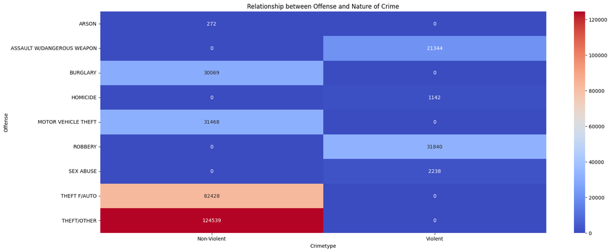

```python
contingency_table = pd.crosstab(df['OFFENSE'], df['crimetype'])
print(contingency_table)
plt.figure(figsize=(20, 8))
sns.heatmap(contingency_table, annot=True, fmt='d', cmap='coolwarm')
plt.title('Relationship between Offense and Nature of Crime')
plt.ylabel('Offense')
plt.xlabel('Crimetype')
plt.show()
```

Following the heat chart, we have another bar chart comparing Neighborhood Clusters, and the division of Violent vs Nonviolent crimes within these clusters. The chart shows the most dangerous neighborhood being Cluster 2, and the safest to be Cluster 29.

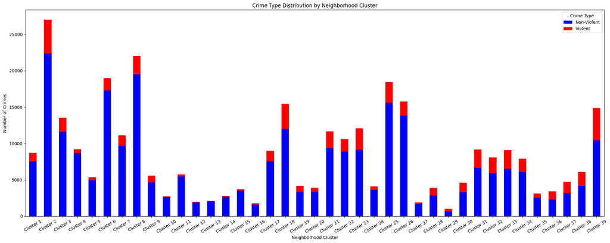

```python
df['Cluster_Number'] = df['NEIGHBORHOOD_CLUSTER'].str.extract('(\d+)').astype(int)
crime_distribution = pd.crosstab(df['NEIGHBORHOOD_CLUSTER'], df['crimetype'])
crime_distribution = crime_distribution.merge(df[['NEIGHBORHOOD_CLUSTER', 'Cluster_Number']].drop_duplicates(), on='NEIGHBORHOOD_CLUSTER')
crime_distribution.sort_values(by='Cluster_Number', inplace=True)
crime_distribution.drop(columns='Cluster_Number', inplace=True)
crime_distribution.set_index('NEIGHBORHOOD_CLUSTER', inplace=True)
crime_distribution.plot(kind='bar', stacked=True, figsize=(20, 8), color=['blue', 'red'])
plt.title('Crime Type Distribution by Neighborhood Cluster')
plt.xlabel('Neighborhood Cluster')
plt.ylabel('Number of Crimes')
plt.xticks(rotation=30)
plt.legend(title='Crime Type')
plt.tight_layout()
plt.show()
```

```python
offenses_per_year = {}
for x in range(len(df)):
    year_val = str(df.iloc[x, 3])[:4]
    offenses_per_year[year_val] = offenses_per_year.get(year_val, 0) + 1

offenses_per_year_sorted = dict(sorted(offenses_per_year.items()))
offenses_per_year_sorted
```

```
{'2008': 33447,
 '2009': 28295,
 '2010': 27848,
 '2011': 29743,
 '2012': 34650,
 '2013': 35255,
 '2014': 37761,
 '2015': 36466,
 '2016': 35467,
 '2017': 26408}
```

To gain a more direct idea of the rate of change over the years, we built a graph displaying the number of crimes committed each year from the beginning of our data model in 2008 to the end of our data model in 2017. We can see that 2014 had the highest number of crimes committed within that range. Afterwards, we further broke down these values into a Yearly Crime Distribution chart showing the number of violent vs. nonviolent offenses per year. Here, we can see what 2008 seemed to have the highest ratio of violent crimes to nonviolent crimes.

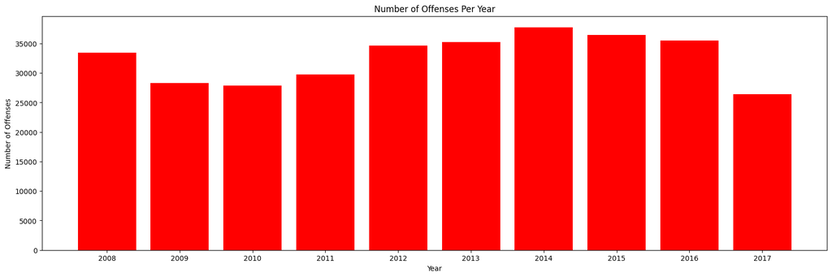

```python
plt.figure(figsize=(20, 6))
plt.bar(list(offenses_per_year_sorted.keys()),list(offenses_per_year_sorted.values()), color="red")
plt.xlabel("Year")
plt.ylabel("Number of Offenses")
plt.title("Number of Offenses Per Year")
plt.show()
```

We were curious to see the most common crimes committed each year, so we printed out the top committed offense per year. Consistently, theft was the most frequent crime every year within our dataset. Similarly, we also wanted to find the most common crime committed in each neighborhood cluster, and were not surprised to see that Theft was once again the most frequent crime committed in every cluster.

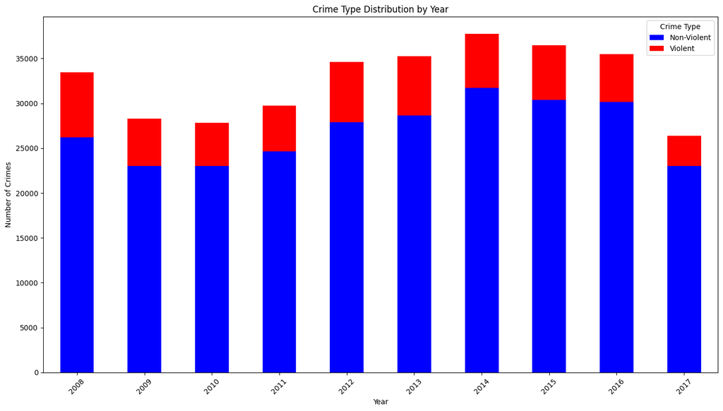

```python
crime_distribution = df.groupby(['year', 'crimetype']).size().unstack(fill_value=0)
crime_distribution.plot(kind='bar', stacked=True, figsize=(14, 8), color=['blue', 'red'])
plt.title('Crime Type Distribution by Year')
plt.xlabel('Year')
plt.ylabel('Number of Crimes')
plt.xticks(rotation=45)
plt.legend(title='Crime Type')
plt.tight_layout()
plt.show()
```

```python
offense_by_year = df.groupby(['year', 'OFFENSE']).size().unstack(fill_value=0)
most_common_offense = offense_by_year.idxmax(axis=1)
most_common_offense_table = pd.DataFrame(most_common_offense, columns=['Most Common Offense Per Year'])
print(most_common_offense_table)
```

```
     Most Common Offense Per Year
year
2008                  THEFT/OTHER
2009                  THEFT/OTHER
2010                  THEFT/OTHER
2011                  THEFT/OTHER
2012                  THEFT/OTHER
2013                  THEFT/OTHER
2014                  THEFT/OTHER
2015                  THEFT/OTHER
2016                  THEFT/OTHER
2017                  THEFT/OTHER
```

```python
offense_by_year = df.groupby(['NEIGHBORHOOD_CLUSTER', 'OFFENSE']).size().unstack(fill_value=0)
most_common_offense = offense_by_year.idxmax(axis=1)
most_common_offense_table = pd.DataFrame(most_common_offense, columns=['Most Common Offense Per Year'])
print(most_common_offense_table)
```

```
                     Most Common Offense Per Year
NEIGHBORHOOD_CLUSTER
Cluster 1                             THEFT/OTHER
Cluster 10                           THEFT F/AUTO
Cluster 11                            THEFT/OTHER
Cluster 12                            THEFT/OTHER
Cluster 13                            THEFT/OTHER
Cluster 14                            THEFT/OTHER
Cluster 15                            THEFT/OTHER
Cluster 16                           THEFT F/AUTO
Cluster 17                            THEFT/OTHER
Cluster 18                            THEFT/OTHER
Cluster 19                           THEFT F/AUTO
Cluster 2                             THEFT/OTHER
Cluster 20                            THEFT/OTHER
Cluster 21                            THEFT/OTHER
Cluster 22                            THEFT/OTHER
Cluster 23                            THEFT/OTHER
Cluster 24                           THEFT F/AUTO
Cluster 25                            THEFT/OTHER
Cluster 26                            THEFT/OTHER
Cluster 27                            THEFT/OTHER
Cluster 28                            THEFT/OTHER
Cluster 29                            THEFT/OTHER
Cluster 3                            THEFT F/AUTO
Cluster 30                            THEFT/OTHER
Cluster 31                            THEFT/OTHER
Cluster 32                            THEFT/OTHER
Cluster 33                            THEFT/OTHER
Cluster 34                            THEFT/OTHER
Cluster 35                            THEFT/OTHER
Cluster 36                            THEFT/OTHER
Cluster 37                            THEFT/OTHER
Cluster 38                            THEFT/OTHER
Cluster 39                            THEFT/OTHER
Cluster 4                             THEFT/OTHER
Cluster 5                             THEFT/OTHER
Cluster 6                             THEFT/OTHER
Cluster 7                            THEFT F/AUTO
Cluster 8                             THEFT/OTHER
Cluster 9                             THEFT/OTHER
```

Our last visual representation before our ML model includes a map of the relevant Washington DC area our dataset focuses on, and color-codes the locations of crimes by nature. Red dots represent violent crimes, and blue dots represent nonviolent crimes. Densely colored areas show the more dangerous parts of the city where crime is incessant, and densely red areas could be places to avoid or be extremely wary of.

For runtime sake, we have attachead the output of the file "dc_crime_map.html" below.

```python
m = folium.Map(location=[df.YBLOCK.mean(), df.XBLOCK.mean()], zoom_start=10)

for i, row in df.iterrows():
    folium.CircleMarker(location=(row['YBLOCK'], row['XBLOCK']),
                        radius=5,
                        color='red' if row['crimetype'] == 'Violent' else 'blue',
                        fill=True,
                        fill_opacity=0.7,
                        popup=row['crimetype']).add_to(m)
m.save('dc_crime_map.html')
```

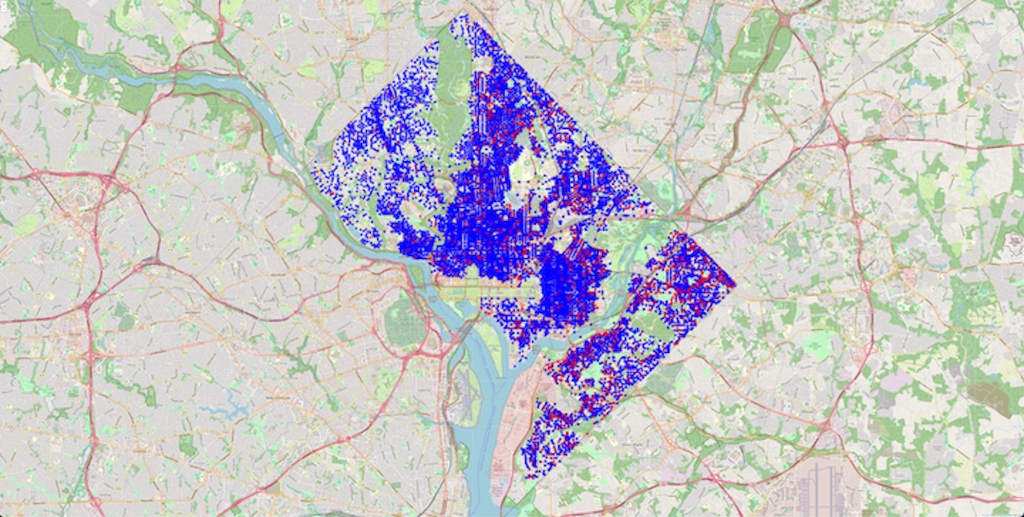

# Machine Learning

Now we can start to use Machine Learning to predict certain attributes that we found interesting throughout the data. One main attribute of any crime is its nature - is it a crime considered to be violent or not. We also explore a prediction for another attribute about the PSA level of a crime. To give context, the PSA level (or Public Safety Assessment) of a crime is a value which demonstrates how likely for the person who committed the crime to show up in court along with remaining arrest free while on pretrial release. For more information, please visit: https://advancingpretrial.org/psa/factors/#:~:text=The%20Public%20Safety%20Assessment%20PSA,free%20while%20on%20pretrial%20release.

For our first model, we will use LogisticRegression. Logistic regression is a method for machine learning which is a binary classifier for predicting the probability of the event occurring. https://www.ibm.com/topics/logistic-regression

We predict the crimeType (either “Violent” or “NonViolent”) based on the following attributes: district of crime, method of crime, the hour of the day, and the time of the day. We used these attributes for our model because we thought these variables would mean the most to tell whether a crime is considered violent or nonviolent.

```python
# Now we can do some machine learning, ALright
# We can use ML to predict the likelyhood of crime being violent or not


#Logistic Regression (Binary Classification)
X = df[['DISTRICT', 'METHOD', 'hour', 'SHIFT']]  # Selecting features
y = df['crimetype']

X = pd.get_dummies(X, columns=['DISTRICT', 'METHOD', 'SHIFT'])

X_train, X_test, y_train, y_test = train_test_split(X, y, test_size=0.001, random_state=42)

model = LogisticRegression(max_iter=1000, random_state=42)
model.fit(X_train, y_train)
y_pred = model.predict(X_test)

print("Accuracy:", accuracy_score(y_test, y_pred))
print("Classification Report:\n", classification_report(y_test, y_pred))
```

```
Accuracy: 0.9233128834355828
Classification Report:
               precision    recall  f1-score   support

 Non-Violent       0.91      1.00      0.96       267
     Violent       1.00      0.58      0.73        59

    accuracy                           0.92       326
   macro avg       0.96      0.79      0.84       326
weighted avg       0.93      0.92      0.91       326
```

Our model predicted around a 92% accuracy rate which is quite efficient for predicting whether a crime is considered to be violent or nonviolent.

We then made a temporary dataframe to store the predicted results from our model. We wanted a side by side comparison to show how accurate it is in predicting a violent or nonviolent crime.

What about the column “OFFENSE”?

```python
X_test['Predicted crimetype'] = y_pred
X_test['Predicted crimetype'] = X_test['Predicted crimetype'].replace({1: "Violent", 0: "Non-Violent"})
X_test['Actual crimetype'] = df.loc[X_test.index, 'crimetype']
X_test
```

|  | hour | DISTRICT_1.0 | DISTRICT_2.0 | DISTRICT_3.0 | DISTRICT_4.0 | DISTRICT_5.0 | DISTRICT_6.0 | DISTRICT_7.0 | METHOD_GUN | METHOD_KNIFE | METHOD_OTHERS | SHIFT_DAY | SHIFT_EVENING | SHIFT_MIDNIGHT | Predicted crimetype | Actual crimetype |
| --- | --- | --- | --- | --- | --- | --- | --- | --- | --- | --- | --- | --- | --- | --- | --- | --- |
| 52187 | 16 | False | True | False | False | False | False | False | False | False | True | False | True | False | Non-Violent | Non-Violent |
| 59775 | 17 | False | True | False | False | False | False | False | False | False | True | False | True | False | Non-Violent | Non-Violent |
| 274061 | 18 | False | False | False | False | False | False | True | False | False | True | False | True | False | Non-Violent | Non-Violent |
| 13705 | 13 | False | True | False | False | False | False | False | False | False | True | True | False | False | Non-Violent | Non-Violent |
| 100264 | 21 | False | False | False | True | False | False | False | False | False | True | False | True | False | Non-Violent | Violent |
| ... | ... | ... | ... | ... | ... | ... | ... | ... | ... | ... | ... | ... | ... | ... | ... | ... |
| 72799 | 13 | False | True | False | False | False | False | False | False | False | True | True | False | False | Non-Violent | Non-Violent |
| 151352 | 1 | False | False | False | False | True | False | False | True | False | False | False | False | True | Violent | Violent |
| 305064 | 10 | False | False | True | False | False | False | False | False | False | True | True | False | False | Non-Violent | Violent |
| 72090 | 22 | False | True | False | False | False | False | False | False | False | True | False | True | False | Non-Violent | Non-Violent |
| 114381 | 13 | False | False | False | False | True | False | False | False | False | True | True | False | False | Non-Violent | Non-Violent |

326 rows × 16 columns

This column details the offense of each crime - whether a crime is considered to be a theft, motor vehicle theft, sex abuse, etc. We made a machine learning model again using Logistic Regression to tell whether a crime is violent or nonviolent. We used our variable OFFENSE to see if there was a direct correlation. Because we saw every prediction being equal to the expected crime type, we jumped to the assumption that there is a dependency between the offense of the crime and nature of the crime. As previously mentioned in our data analysis, the heat chart clearly has a binary classification whether a specific offense is violent or not. For example, theft and burglary cases are classified as nonviolent whereas crimes like sex abuse, robbery, etc are considered to be violent.

```python
X = df[['OFFENSE']]
y = df['crimetype']
X = pd.get_dummies(X, columns=['OFFENSE'])
X_train, X_test, y_train, y_test = train_test_split(X, y, test_size=0.001, random_state=42)
model = LogisticRegression(max_iter=1000)
model.fit(X_train, y_train)
y_pred = model.predict(X_test)
print("Accuracy:", accuracy_score(y_test, y_pred))
print("Classification Report:\n", classification_report(y_test, y_pred))

#The model will  predict the crimetype given a offense because
#crimeType attribute is dependent on offense.
```

```
Accuracy: 1.0
Classification Report:
               precision    recall  f1-score   support

 Non-Violent       1.00      1.00      1.00       267
     Violent       1.00      1.00      1.00        59

    accuracy                           1.00       326
   macro avg       1.00      1.00      1.00       326
weighted avg       1.00      1.00      1.00       326
```

Next, we wanted to predict the PSA of a crime using machine learning. We used a RandomForestClassifier. What this does is it creates a random sample and subgroups each sample, creating decision trees for each sample. When a new datapoint is passed into the classifier, it passes it into a decision tree and is given a tally mark for what class it deserves to be in the most. With the use of RandomForestClassiifer, our data is less prone to overfitting as well as the model handling noisy data better.

For more on Random Forest, see https://scikit-learn.org/stable/modules/generated/sklearn.ensemble.RandomForestClassifier.html

We used the columns for the x and y coordinates, the hour of the day, the district, the ward, the offense, as well as the method for the crime.

Our model has around a 94% accuracy which is very solid for determining the PSA for a given crime.

```python
# Find as many features to predict PSA
X = pd.get_dummies(df[['XBLOCK', 'YBLOCK', 'hour', 'DISTRICT', 'WARD', 'OFFENSE', 'METHOD']], drop_first=True)
y = df['PSA']
X_train, X_test, y_train, y_test = train_test_split(X, y, test_size=0.3, random_state=42)
model = RandomForestClassifier(n_estimators=100, random_state=42)
model.fit(X_train, y_train)
y_pred = model.predict(X_test)
print("Accuracy:", accuracy_score(y_test, y_pred))
print("Classification Report:\n", classification_report(y_test, y_pred))
```

```
Accuracy: 0.9457183254441507
Classification Report:
               precision    recall  f1-score   support

       101.0       0.95      0.90      0.93      2165
       102.0       0.93      0.92      0.92      2380
       103.0       0.89      0.90      0.90      1271
       104.0       0.93      0.94      0.94      2839
       105.0       0.92      0.94      0.93      1566
       106.0       0.93      0.91      0.92      1605
       107.0       0.93      0.93      0.93      2845
       108.0       0.92      0.94      0.93      1930
       201.0       0.99      0.98      0.98       770
       202.0       0.98      0.98      0.98      1730
       203.0       0.94      0.96      0.95      1041
       204.0       0.96      0.96      0.96      1502
       205.0       0.98      0.94      0.96       705
       206.0       0.99      0.99      0.99      2731
       207.0       0.97      0.98      0.98      3562
       208.0       0.98      0.97      0.97      3720
       301.0       0.91      0.90      0.90      1793
       302.0       0.97      0.97      0.97      3528
       303.0       0.96      0.96      0.96      2295
       304.0       0.92      0.94      0.93      1878
       305.0       0.92      0.92      0.92      2724
       306.0       0.87      0.86      0.87      1031
       307.0       0.94      0.95      0.94      1934
       308.0       0.96      0.94      0.95      1534
       401.0       0.98      0.97      0.97      1310
       402.0       0.96      0.95      0.96      1617
       403.0       0.94      0.95      0.95      1579
       404.0       0.92      0.92      0.92      1711
       405.0       0.98      0.98      0.98      1586
       406.0       0.95      0.96      0.96       923
       407.0       0.91      0.91      0.91      1362
       408.0       0.97      0.97      0.97       977
       409.0       0.94      0.96      0.95      1687
       501.0       0.94      0.94      0.94      2251
       502.0       0.93      0.93      0.93      1670
       503.0       0.96      0.97      0.97      1919
```

[output cut: 9 more lines]

```
       606.0       0.97      0.97      0.97       967
       607.0       0.92      0.94      0.93      1128
       608.0       0.90      0.94      0.92      1563
       701.0       0.96      0.95      0.95      1550
       702.0       0.93      0.95      0.94       989
       703.0       0.97      0.95      0.96      1397
       704.0       0.98      0.99      0.98      1509
       705.0       0.92      0.93      0.93      1006
       706.0       0.96      0.94      0.95      1191
       707.0       0.93      0.93      0.93      1120
       708.0       0.93      0.95      0.94      1348

    accuracy                           0.95     97602
   macro avg       0.94      0.94      0.94     97602
weighted avg       0.95      0.95      0.95     97602
```

Below is another side by side comparison for the actual PSA vs the predicted PSA. As you can see, we used only the top 20 values from our dataframe. This shows the similarities between our machine learning output with the expected values. From what you can see, the values are very close, implying the Random Forest Classifier is a very great tool for determining the PSA of a given crime.

```python
temp_df = pd.DataFrame({
    'Actual PSA': y_test,
    'Predicted PSA': y_pred
})
temp_df.reset_index(drop=True, inplace=True)
temp_df.head(20)
matches = (temp_df['Actual PSA'] == temp_df['Predicted PSA']).sum()
total_predictions = len(temp_df)
accuracy = matches / total_predictions
print(f'Accuracy to predict PSA using Random Forest: {accuracy * 100}%')
temp_df.head(20)
```

```
    Actual PSA  Predicted PSA
0        207.0          207.0
1        206.0          206.0
2        703.0          703.0
3        207.0          207.0
4        403.0          403.0
5        603.0          603.0
6        701.0          701.0
7        307.0          307.0
8        204.0          204.0
9        505.0          505.0
10       103.0          103.0
11       302.0          302.0
12       507.0          507.0
13       208.0          208.0
14       205.0          205.0
15       409.0          409.0
16       208.0          208.0
17       604.0          604.0
18       706.0          706.0
19       501.0          501.0
Accuracy to predict PSA using Random Forest: 94.57183254441507%
```

# Conclusion

### Closing Thoughts

We can conclude that crime is very common in Washington DC. DC crime can happen all over the area, as shown in the map. Most crimes are nonviolent, but that doesn’t mean it isn’t a subject of concern. It is important to take the proper precautions when visiting or traveling in the city to make sure you and your loved ones are safe.

For more information regarding general safety advised from Washington DC: https://mpdc.dc.gov/page/general-safety